# Neither Spouse Nor Kin: The Denver Residents Classified as 'Partners' in the 1900 Federal Census

#### Final Project for Data: A User Manual (CU Denver, Fall 2021)

# Introduction

For over a year now, I have been working on a project to locate the earliest traceable evidence of queer individuals and communities in post-colonial Denver. Using Denver City Directories from 1870-1914 and Sanborn Fire Insurance Maps, I mapped potentially-queer events or individuals that gained visibility through newspaper articles and police reports. The results revealed a tight cluster (with a one and a half block radius) of six out seven of the locatable instances of non-vaudevillian “female impersonation” between 1877 and 1901. Locations of potential “sodomy” occurrences—the other archetypal instance of cis-male queer behavior or individuals—however, seemed to loosely follow streetcar routes more widely within the working-class neighborhoods of the city. Historians who have studied queer neighborhoods in other cities during the pre-World War I era through the 1920s have consistently pointed to the existence of a small community of “female impersonators” in each city. They were often described as “male” prostitutes who adopted effeminate names, garments, and mannerisms to visibly indicate their sexual availability to men from outside of their community. This pattern supported the likelihood that I was looking at such a community in Denver, however, my timeline (1877-1901) was earlier than any of the examples from New York City, Portland, San Francisco, or Chicago. (Chauncey,47-62; Jim Elledge, 14-27; Boag, loc. 1213-1244)

[figure not shown]

Flash forward to this past October, I read Dan Bouk’s blog [entry](https://censusstories.us/2018/07/03/partners.html) about his small exploration into the “Partners” of Greenwich Village. Prompted by the research of [Ansley Erickson](https://www.tc.columbia.edu/faculty/ate11/), Bouk sought to find out if those labeled as a “Partner” to the “Head” of a household in the 1940 Federal Census could ever indicate the presence of queer individuals or communities. Bouk calculated the likelihood—from the total entries of partners in the census—that a given enumerator would record a partner in their assigned district. He calculated that an average of less than three (2.96) partners were recorded by each enumerator, however the enumerator who recorded the data from Greenwich Village in NYC—a widely known “gay neighborhood” during this era according to George Chauncey—recorded twelve partners within her district alone. At first glance this would strongly support the existence of a queer neighborhood, so I decided to apply the same method to my own research about Denver. As I studied and mapped the nearly 160 census recordings of “Partners” in Denver in 1900--the earliest year to use the label, at least in Denver--I asked myself two overarching questions: are there queer individuals represented within this data? And, can these individuals indicate or confirm the existance of larger queer communities?

```python
import pandas as pd
import os
```

# Methodology

Thanks to the accessible and searchable databases of ancestry.com, I was able to filter through the 1900 Federal Census to list all those who were labeled as a “Partner” in Denver. As I mentioned above, the search returned nearly 160 census entries, from which I transcribed twenty-two values of data for each individual onto a spreadsheet, ranging from "Marital Status" to the "Occupation of [the] Head [of the household]." This proved to be a challenge, especially when I encountered messy penmanship or data that had been obscured during the digitization process. In these cases I wrote "illegible" for the value of the given row. I exported the spreadsheet as a csv (coma separated value) file named "**1900-Denver-Partners-Census.csv**," and saved it to my Project folder for easy accessibility. I was then able to open and read the csv file with the Python command **pd.read_cvs()** by inserting the filepath "1900-Denver-Partners-Census.csv" within the parentheses, which produced a table of the data contained in the csv file.

```python
pd.read_csv("1900-Denver-Partners-Census.csv")
```

|  | Name | Age | Location | Birth Month | Birth Year | Birthplace | Race | Gender | Marital Status | Naturalization | ... | Can Read | Can Write | Can Speak English | Size of Household | Gender of Head | Occupation of Head | Birthplace of Head | Age of Head | Shared Surname | Head Marital |
| --- | --- | --- | --- | --- | --- | --- | --- | --- | --- | --- | --- | --- | --- | --- | --- | --- | --- | --- | --- | --- | --- |
| 0 | M H Comstock | 49.0 | 800 9th ave, Denver, Colorado | 12.0 | 1850.0 | USA | white | male | single | wes | ... | yes | yes | yes | 2 | male | laborer | Germany | 50.0 | no | single |
| 1 | Mary Cresto | 50.0 | 1527 16th st mall, Denver, Colorado | 1.0 | 1850.0 | Italy | white | female | married | unknown | ... | no | no | yes | 7 | female | saloon keeper | Italy | 27.0 | no | single |
| 2 | Harry Crampton | 21.0 | 1836 Glenarm pl, Denver, Colorado | 5.0 | 1879.0 | USA | white | male | single | NaN | ... | yes | yes | yes | 4 | male | hostler | Ireland | 35.0 | no | single |
| 3 | Harry Cook | 32.0 | 1836 Glenarm pl, Denver, Colorado | 6.0 | 1868.0 | USA | white | male | single | NaN | ... | yes | yes | yes | 4 | male | hostler | Ireland | 35.0 | no | single |
| 4 | Mason J Coleman | 22.0 | 514 15th st, Denver, Colorado | 6.0 | 1877.0 | USA | white | male | single | NaN | ... | yes | yes | yes | 2 | male | elevator pilot | NaN | 27.0 | no | single |
| ... | ... | ... | ... | ... | ... | ... | ... | ... | ... | ... | ... | ... | ... | ... | ... | ... | ... | ... | ... | ... | ... |
| 151 | Grace Doolittle | 28.0 | 1375 S 15th St, Denver, Colorado | 2.0 | 1872.0 | USA | white | female | single | NaN | ... | yes | yes | yes | 2 | female | dressmaker | USA | 32.0 | no | divorced |
| 152 | Peter Darnashos | 32.0 | 1410 Curtis St, Denver, Colorado | 4.0 | 1868.0 | Greece | white | male | single | alien | ... | yes | yes | yes | 3 | male | confectionary | Greece | 40.0 | no | married |
| 153 | Grace Anderson | 17.0 | 908 18th St, Denver, Colorado | 9.0 | 1882.0 | USA | white | female | single | NaN | ... | yes | yes | yes | 5 | female | NaN | USA | 45.0 | no | married |
| 154 | Amanda Anderson | 37.0 | 1640 Welton St, Denver, Colorado | 10.0 | 1862.0 | USA | white | female | single | NaN | ... | yes | yes | yes | 7 | female | dressmaker | USA | 27.0 | no | married |
| 155 | Richie Ambrose | 24.0 | 1319 S 15th St, Denver, Colorado | 5.0 | 1876.0 | USA | white | female | single | NaN | ... | yes | yes | yes | 8 | female | servant | USA | 33.0 | no | single |

156 rows × 22 columns

I assigned the csv file to a dataframe (df) to create a shortcut to the command **pd.read_csv("1900-Denver-Partners-Census.csv")**. For simplicity, I named this dataframe "**denver_df**." That process looked like the following:

```python
denver_df = pd.read_csv("1900-Denver-Partners-Census.csv")
```

Because I defined this new datafame (using the = sign) as the command to read my csv file, if I were to run denver_df it would show the same table as above, same as the result for the command pd.read_cvs(). Therefore, if I wanted to produce a random sample of five census entries, I would use the following:

```python
denver_df.sample(5)
```

|  | Name | Age | Location | Birth Month | Birth Year | Birthplace | Race | Gender | Marital Status | Naturalization | ... | Can Read | Can Write | Can Speak English | Size of Household | Gender of Head | Occupation of Head | Birthplace of Head | Age of Head | Shared Surname | Head Marital |
| --- | --- | --- | --- | --- | --- | --- | --- | --- | --- | --- | --- | --- | --- | --- | --- | --- | --- | --- | --- | --- | --- |
| 125 | Henry Hendricks | 25.0 | 3925 Franklin St, Denver, Colorado | NaN | 1875.0 | USA | black | male | single | NaN | ... | yes | yes | yes | 2 | male | stone cutter | USA | 37.0 | no | widowed |
| 45 | Wah Yin | 45.0 | 1622 Court Place, Denver, Colorado | 11.0 | 1854.0 | China | chinese | male | single | alien | ... | yes | yes | yes | 6 | male | laundry man | China | 34.0 | no | married |
| 96 | John Lyons | 56.0 | 1007 York St, Denver, Colorado | 6.0 | 1865.0 | Ireland | white | male | single | naturalized | ... | yes | yes | yes | 2 | male | day laborer | Ireland | 39.0 | no | married |
| 126 | Wah Hee | 47.0 | 1935 Blake St, Denver, Colorado | 4.0 | 1853.0 | China | chinese | male | single | NaN | ... | yes | yes | yes | 2 | male | laundry owner | China | 37.0 | no | single |
| 129 | Lizzie Grover | 56.0 | 2430 Walnut st, Denver, Colorado | 12.0 | 1843.0 | USA | white | female | married | NaN | ... | yes | yes | yes | 3 | male | paper hanger | USA | 32.0 | no | married |

5 rows × 22 columns

Once my data set was assigned to a workable dataframe, my next task was to cross-analyse the data through various filters, and eventually to map them. To do this, I had to define a function that applied one or more conditions to the **denver_df** dataframe. These took the form of simple equations that selected a column within the dataframe and stated a condition to be applied to the value, such as **"Birthplace" == "USA,"** which searches through the dataframe and only selects individuals who were born in the United States. If I wanted to further specify that this filter should also display households with only two people ("Size of Household" == 2), I simply connected the statements with an "&" symbol, allowing me to add as many conditions and I desired to a given filter. Therefore, if I wanted to create a filter that--when applied to the denver_df dataframe--only showed me individuals who were both American-born and lived in a household of only two people, I would run the following code:

```python
american_pairs_filter = (denver_df['Birthplace']=='USA') & (denver_df['Size of Household'] == 2)
```

I then had to turn the filter into its own dataframe that could be passed through various functions, from data summaries to geolocated maps. Like many of the processes up this point, this only required a simple defining statement that assigned the filtered results from denver_df to a new dataframe called **american_pairs_df**.

```python
american_pairs_df = denver_df[american_pairs_filter]
```

This new dataframe will only display individuals within the dataset who meet both the conditions of American-born and living in a household size of 2.

```python
american_pairs_df.sample(5)
```

|  | Name | Age | Location | Birth Month | Birth Year | Birthplace | Race | Gender | Marital Status | Naturalization | ... | Can Read | Can Write | Can Speak English | Size of Household | Gender of Head | Occupation of Head | Birthplace of Head | Age of Head | Shared Surname | Head Marital |
| --- | --- | --- | --- | --- | --- | --- | --- | --- | --- | --- | --- | --- | --- | --- | --- | --- | --- | --- | --- | --- | --- |
| 105 | Louis C Joslin | 24.0 | 517 16th St mall, Denver, Colorado | 5.0 | 1876.0 | USA | white | male | single | NaN | ... | yes | yes | yes | 2 | male | commercial traveler | USA | 27.0 | no | single |
| 140 | Allen Gladson | 29.0 | 1434 Wazee St, Denver, Colorado | 10.0 | 1870.0 | USA | white | male | single | NaN | ... | yes | yes | yes | 2 | male | hostler | USA | 25.0 | no | single |
| 68 | Mike Schafer | 40.0 | 1845 Welton St, Denver, Colorado | 2.0 | 1860.0 | USA | white | male | single | NaN | ... | yes | yes | yes | 2 | male | carriage driver | USA | 35.0 | no | NaN |
| 69 | May Rich | 22.0 | 510 16th St mall, Denver, Colorado | 3.0 | 1878.0 | USA | white | female | single | NaN | ... | yes | yes | yes | 2 | female | waitress | USA | 27.0 | no | single |
| 92 | Ella Marshall | 22.0 | 2640 Walnut st, Denver, Colorado | 6.0 | 1877.0 | USA | black | female | single | NaN | ... | yes | yes | yes | 2 | female | laundress | USA | 25.0 | no | single |

5 rows × 22 columns

In order to visualize this filter (and others) in a pie chart, I plugged our new dataframe into the **df.value_counts().plot()** command, using the index function to specify how many values the chart should list (starting from the most common within the data set), and filling the plot parentheses with specifications about the type, size, and title of the chart. I also selected the column within the data set that I want plotted, choosing "Gender," which will show us how many American-born pairs were recorded as male vs. female.

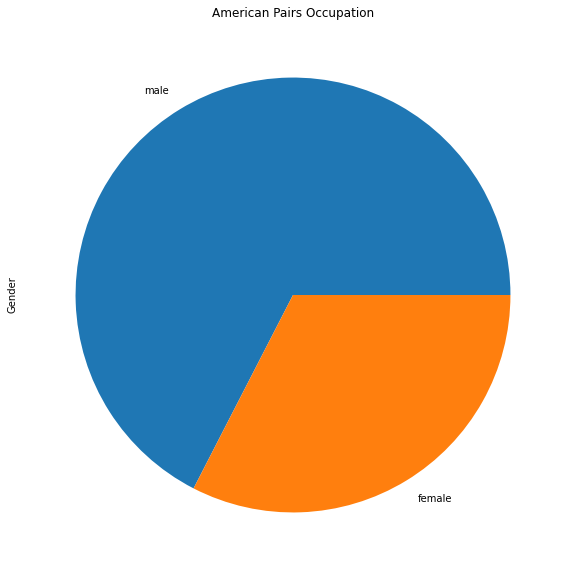

```python
american_pairs_df['Gender'].value_counts()[:10].plot(kind='pie', figsize=(10, 10), title='American Pairs Occupation')
```

This filter can only tell us a small fragment of the story of this dataset, so naturally I created and graphed many filters of varying complexities to incorporate within my analysis. The final step, however, was to map these filters so that I could identify potential patterns of settlement among the different demographics represented in the data set.

In order to begin mapping these filters, I needed to install a Python package named GeoPy to give me access to a range of geocoding API services. I was able to do this with the **!pip** command, which installs Python packages (**!pip install geopy**). Because it does not require an API key, I chose the program Nominatum among GeoPy's API services to read the addresses contained within the dataframe and produce geographic coordinates. I was able to import the program from the newly installed GeoPy with the following command:

```python
from geopy.geocoders import Nominatim
```

I now needed a variable through which to run Nominatum, much like how I assigned the command to read my csv file to the dataframe denver_df. I assigned the variable "geolocator" to the program, naming the process "Teddy's mapping app" for clarity. Now, in order to use Nominatum's API services, I could plug in the more-compatible command of "geolocator."

```python
geolocator = Nominatim(user_agent="Teddy's mapping app", timeout=2)
```

To obtain the actual longitudes and latitudes of each listed address, I first had to define a function that applied the "geolocator" command to the "Location" column in my csv file. Therefore in the following code, I assigned "place" to the "Location" column, and then assigned the geocode command to "location," specifying "place" in the parentheses in order to apply geocoding to the "Location". Finally, I specified for the code to "return" the geolocated "address" , "latitude," "longitude," and "importance." If a "Location" was left blank in a given row, I specified for the function to return the phrase "Not Found."

```python
def find_location(row):

    place = row['Location']

    location = geolocator.geocode(place)

    if location != None:
        return location.address, location.latitude, location.longitude, location.raw['importance']
    else:
        return "Not Found", "Not Found", "Not Found", "Not Found"
```

With the "find_location" command defined, I applied it to the dataframe denver_df with the **df.apply()** function, filling the parentheses with the new command. I also included specifications that the command was supposed to be applied to the "columns" axis (x-axis) and that this function should "expand" the resulting table.

```python
denver_df[['address', 'lat', 'lon', 'importance']] = denver_df.apply(find_location, axis="columns", result_type="expand")
```

```python
denver_df.sample(5)
```

[output not shown]

5 rows × 22 columns

Once every address returned a viable location, I created a new csv file to work with because the updated version contained the geographic coordinates required to map the data set. To do this, I used the **df.to_csv()** command to create a new file using the updated information applied to denver_df and filling the parentheses with the desired name of the new csv file. I named it **location-denver-partners.csv**.

```python
denver_df.to_csv('location-denver-partners.csv')
```

Much like I did earlier with the original csv file (1900-Denver-Partners-Census.csv), I assigned this updated version to a dataframe to make it more compatible with Pandas. I named this new dataframe **locate_partners_df** to have a clear indication of what running the command *does*, which is to locate all individuals in Denver who were listed as a "Partner" to the head of the household in the 1900 Federal Census.

```python
locate_partners_df = pd.read_csv("location-denver-partners.csv")
```

However, in order to digitally map all of the legible addresses in my dataset, I needed to import a Python library called "Folium," which contained an open-source repository of interactive digital maps. I also had to define a function that would load the map to a default set of geographic coordinates and a default zoom level. Keeping it simple, I named this function **denver_map**.

```python
import folium
```

```python
denver_map = folium.Map(location=[39.75, -105.005], zoom_start=15)
```

If you were to run this fuction on its own, it would generate a blank OpenStreetMap-generated map of the city of Denver. However, my goal was to create a map with individual pins marking each address recorded in my data set. Therefore I established the command **create_map_markers** to create pins using folium and the values listed in the "lat" and "lon" columns. I completed this code with the **add_to()** command, filling the parentheses with "denver_map" and therefore specifying which map these pins were supposed to be added to. Once create_map_markers was fully defined, I used the **df.apply()** command to apply this new function to the locate_partners_df, which took the coordinates listed in the dataframe and marked each one on the denver_map.

```python
def create_map_markers(row, map_name):
    folium.Marker(location=[row['lat'], row['lon']], popup=row['Name'],icon=folium.Icon(color="gray",icon="user", prefix='fa')).add_to(denver_map)

denver_map = folium.Map(location=[39.75, -105.005], zoom_start=15)
locate_partners_df.apply(create_map_markers, map_name=denver_map, axis='columns')
denver_map
```

Make this Notebook Trusted to load map: File -> Trust Notebook

[interactive chart not shown]

**Map 1 - All Denver Partners**

Like I did before, I wanted to create several demographic filters through which to map and hopefully gain insights into the settlement patterns of both the dominant and marginalized populations. In order to map a given filter, I simply applied the create_map_markers function to a filtered dataframe (i.e. american_pairs_df) rather than to "locate_partners_df" in cell 54:

```python
american_pairs_filter = (locate_partners_df['Birthplace']=='USA') & (locate_partners_df['Size of Household'] == 2)
american_pairs_df = locate_partners_df[american_pairs_filter]
```

```python
def create_map_markers(row, map_name):
    folium.Marker(location=[row['lat'], row['lon']], popup=row['Name'],icon=folium.Icon(color="red",icon="user", prefix='fa')).add_to(denver_map)
```

```python
denver_map = folium.Map(location=[39.75, -105.005], zoom_start=15)
american_pairs_df.apply(create_map_markers, map_name=denver_map, axis='columns')
denver_map
```

Make this Notebook Trusted to load map: File -> Trust Notebook

[interactive chart not shown]

**Map 2 - American-Born Pairs**

If I wished to change the lable that pops up when you click on a pin (right now it displays the "Name" of the individual), I would re-define the create_map_markers function and place a different column heading within the brackets of the "popup=row[ ]" command. Therefore, if I wanted to see the "Occupation" of the individuals on this map to add another dimension of analysis, I would change the code as follows:

```python
def create_map_markers(row, map_name):
    folium.Marker(location=[row['lat'], row['lon']], popup=row['Occupation'],icon=folium.Icon(color="red",icon="user", prefix='fa')).add_to(denver_map)
```

Now, if you re-run cell 66, each pin should produce the "Occupation" of the individual rather than their "Name." As a matter of fact, I could plug in any column heading from the data set in this way, essentially adding another filter through which to analyze the mapped data. Through this process, I conducted my analysis of the Partners of 1900 Denver.

# Main Analysis

When I cross-analyzed the various filtered dataframes, several smaller demographical stories began to take form, as well as a larger picture of a predominantly working-class population living in varying degrees of financial and racial vulnerability. One particularly defining aspect of the households that contained people labled as "partner[s]" was that multiple incomes were needed to support the inhabitants. While some households evidently only required two incomes, a little more than half of all the "partner[s]" in Denver came from households of three or more working individuals. Given the working-class nature of nearly all of the occupations listed, it seems reasonable to suppose that those who lived in larger households did so to live under less financial strain, and that living in smaller (unrelated) groups was a luxury not everyone could afford. Therefore, the lable of "partner" in Denver's 1900 Census was primarily used to reflect a financial arrangement that, by nature, classified the household inhabitants as well outside of the relative financial stability of the middle class.

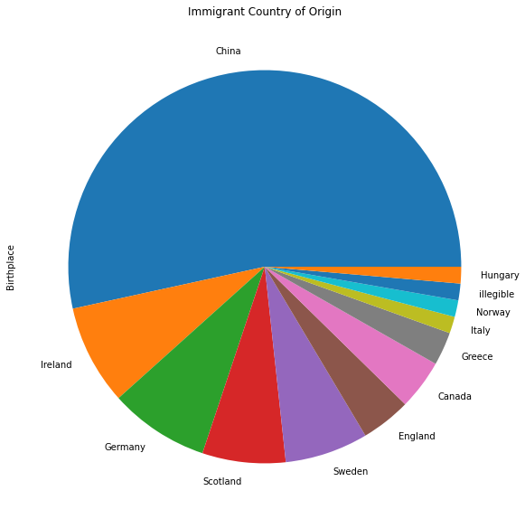

```python
immigrant_filter = (denver_df['Birthplace']!='USA')
immigrant_df = denver_df[immigrant_filter]

immigrant_df['Birthplace'].value_counts()[:20].plot(kind='pie', figsize=(10, 10), title='Immigrant Country of Origin')
```

### Occupation by Naturalization

Of all 73 immigrant partners, only 13 women were recorded, none of whom immigrated from China. Conversely, of the 83 American-born subjects in the data set, 31 were labeled as women. Nearly all of the subjects (from all demographics) worked in working-class occupations, but as you can see from the following pie charts, the occupations available to certain populations were restricted to those that were believed to be socially "acceptable" for certain demographics.

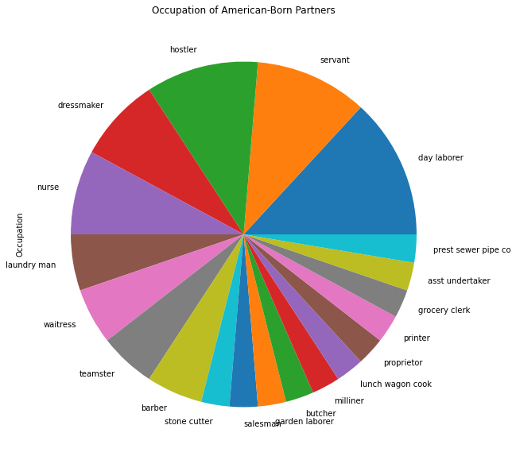

```python
amer_filter = (denver_df['Birthplace']=='USA')
amer_df = denver_df[amer_filter]
amer_df['Occupation'].value_counts()[:20].plot(kind='pie', figsize=(10, 10), title='Occupation of American-Born Partners')
```

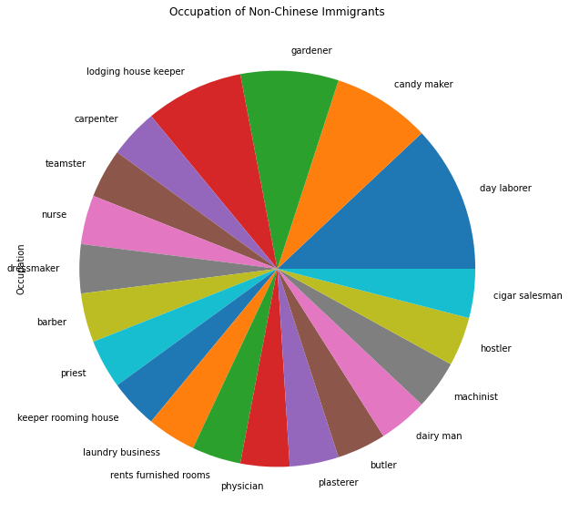

```python
non_chi_imm_filter = (denver_df['Birthplace']!='China')&(denver_df['Birthplace']!='USA')
non_chi_imm_df = denver_df[non_chi_imm_filter]
non_chi_imm_df['Occupation'].value_counts()[:20].plot(kind='pie', figsize=(10, 10), title='Occupation of Non-Chinese Immigrants')
```

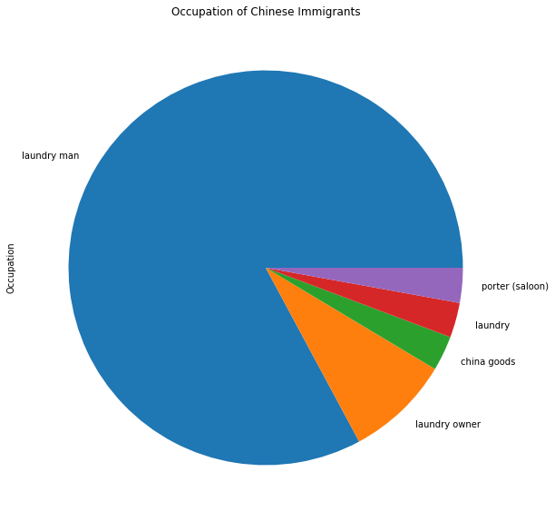

```python
chi_filter = (denver_df['Birthplace']=='China')
chi_df = denver_df[chi_filter]
chi_df['Occupation'].value_counts()[:20].plot(kind='pie', figsize=(10, 10), title='Occupation of Chinese Immigrants')
```

### Occupation by Race

According to these charts, race drastically affected the occupations that were available to a person more than a person's immigrant status. The only three races listed in the data set were "white" (108 subjects), "chinese" (41 subjects), and "black" (7 subjects). If we were to shift gears toward race rather than naturalization, the true differences in the occupations that were available to the white vs. non-white population becomes glaringly apparent, even with the large discrepancies in population size.

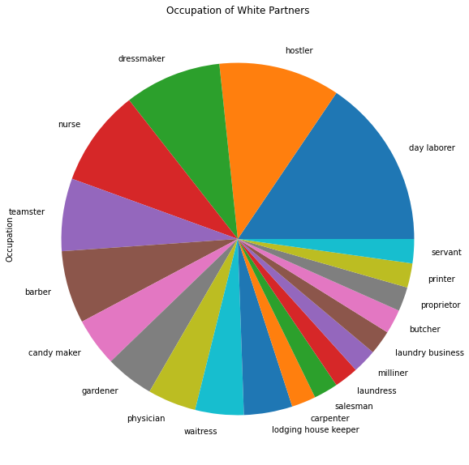

```python
white_filter = (denver_df['Race']=='white')
white_df = denver_df[white_filter]
white_df['Occupation'].value_counts()[:20].plot(kind='pie', figsize=(10, 10), title='Occupation of White Partners')
```

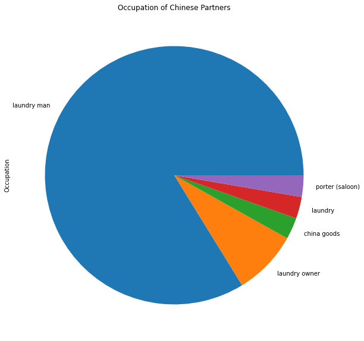

```python
chi_race_filter = (denver_df['Race']=='chinese')
chi_race_df = denver_df[chi_race_filter]
chi_race_df['Occupation'].value_counts()[:20].plot(kind='pie', figsize=(10, 10), title='Occupation of Chinese Partners')
```

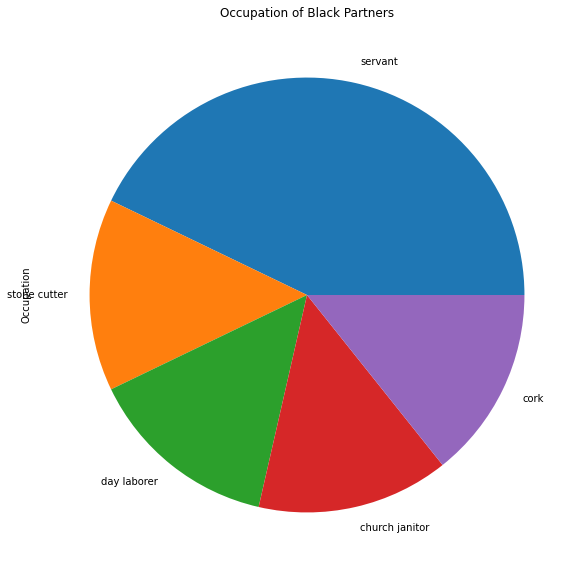

```python
black_filter = (denver_df['Race']=='black')
black_df = denver_df[black_filter]
black_df['Occupation'].value_counts()[:20].plot(kind='pie', figsize=(10, 10), title='Occupation of Black Partners')
```

There's nothing ambiguous about the occupational niches that Chinese and Black residents were restricted to. While white working-class residents of 1900 Denver worked an array of manual labor, skilled labor, and service jobs, the overwhelming majority of Chinese residents were restricted to "laundry" work, while Black residents were mainly servants or manual laborers.

### Size of Household by Race

With such an obviously restricted job market for residents of color, it seems plausible that these households found themselves under greater financial strain than their white counterparts, and were therefore more likely to live in groups of three or more housemates to save on the cost of urban living. The following three pie charts display the proportion of each racial population that lived in households of various sizes:

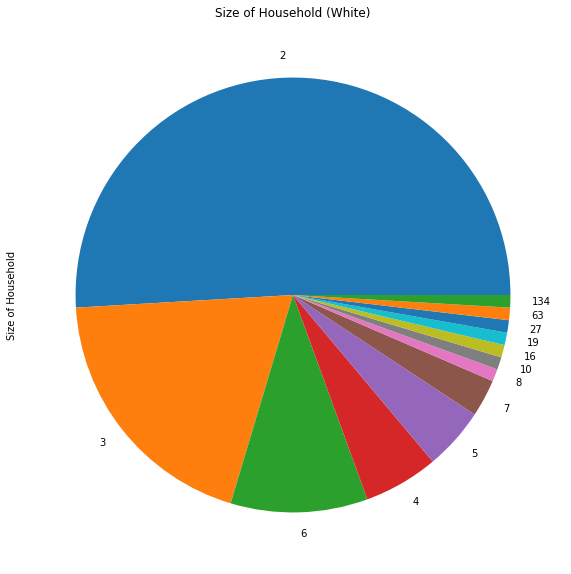

```python
white_df['Size of Household'].value_counts()[:20].plot(kind='pie', figsize=(10, 10), title='Size of Household (White)')
```

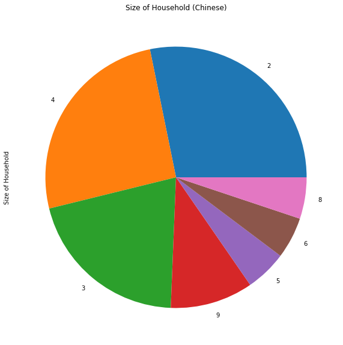

```python
chi_df['Size of Household'].value_counts()[:20].plot(kind='pie', figsize=(10, 10), title='Size of Household (Chinese)')
```

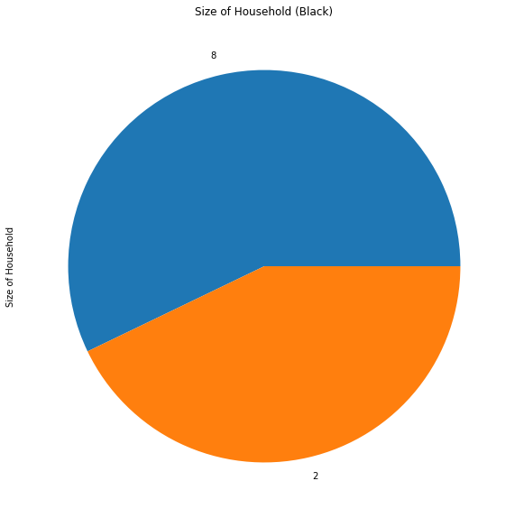

```python
black_df['Size of Household'].value_counts()[:20].plot(kind='pie', figsize=(10, 10), title='Size of Household (Black)')
```

While significantly more white individuals lived in group-living situations (three or more housemates) than either the Chinese or Black populations, this seems to be due only to their status as the overwhelming racial majority. In fact, those who lived in pairs (only two housemates) still constituted the narrow majority of white households. This lends me to believe that my earlier hypothesis, that larger households reflected greater financial vulnerability, is at least partially true. Therefore, it begs the questions: why did pairs of individuals (who were not spouses or blood-relations) choose to live together? Was it out of financial necessity? Or was there another reason?

A personal bias that I believe is necessary to point out is that I primarily processed and analyzed this dataset through a queer lens, searching particularly for indications of same-sex couples and possibly larger queer communities. This certainly affected my research process throughout as limited time frames often require one to bookend their focus in order to be productive. Though my analysis takes most demographics into account, from this point onward I will focus on those who lived in pairs and the various factors that potentially enabled or restricted the formation of such unconventional (for the period) household units.

### Mapping Denver's Pairs

In order to gain a clearer picture of the factors that potentially facilitated the settlement of pairs, I needed to see the spatial relationship (or lack thereof) between the different demographic groups contained within the data set. Therefore, I applied dozens of different filters to the dataframe **locate_partners_df** (the one that contained the longitude and latitude measurements of each address) to see if I could notice any patterns. Indeed, there were three primary details that caught my eye.  
The first was the settlement pattern of the different immigrant groups. While non-Chinese immigrants often housed together with fellow countrymen/women, they seemed to settle near their places of employement rather than within larger ethnic communities. Chinese immigrants, on the other hand, settled in three distinct clusters and were rarely found outside of these apparent enclaves. While mapping the addresses of Denver's white immigrant groups displayed little spatial connection to other ethnically-related households, the following map shows the clear clustering of Chinese individuals within their own communities:

```python
chinese_all_filter = (locate_partners_df['Race']=='chinese')
chinese_all_df = locate_partners_df[chinese_all_filter]
chinese_all_df.sample(3)
```

|  | Unnamed: 0 | Name | Age | Location | Birth Month | Birth Year | Birthplace | Race | Gender | Marital Status | ... | Gender of Head | Occupation of Head | Birthplace of Head | Age of Head | Shared Surname | Head Marital | address | lat | lon | importance |
| --- | --- | --- | --- | --- | --- | --- | --- | --- | --- | --- | --- | --- | --- | --- | --- | --- | --- | --- | --- | --- | --- |
| 38 | 38 | Yen Yee | 44.0 | 328 16th St mall, Denver, Colorado | 5.0 | 1856.0 | China | chinese | male | married | ... | male | laundry man | China | 51.0 | no | married | 328, 16th Street Mall, Central Business Distri... | 39.742675 | -104.989082 | 0.631 |
| 24 | 24 | Soo Han | 43.0 | 1822 California st, Denver, Colorado | 6.0 | 1857.0 | China | chinese | male | single | ... | male | laundry man | China | 36.0 | no | single | 1822, California Street, Central Business Dist... | 39.747328 | -104.988918 | 0.531 |
| 37 | 37 | Say Yee | 35.0 | 1636 16th St mall, Denver, Colorado | 6.0 | 1864.0 | China | chinese | male | single | ... | male | laundry man | China | 37.0 | no | single | 1636, 16th Street Mall, Denver, Denver County,... | 39.751363 | -105.000364 | 0.631 |

3 rows × 27 columns

```python
def create_map_markers(row, map_name):
    folium.Marker(location=[row['lat'], row['lon']], popup=row['Occupation'],icon=folium.Icon(color="blue",icon="user", prefix='fa')).add_to(denver_map)

denver_map = folium.Map(location=[39.75, -105.005], zoom_start=15)
chinese_all_df.apply(create_map_markers, map_name=denver_map, axis='columns')
denver_map
```

Make this Notebook Trusted to load map: File -> Trust Notebook

[interactive chart not shown]

**Map 3 - All Chinese Partners**

The top cluster of map pins--encompassing the area between 19th and 23rd Streets, and Blake and Curtis Streets--generally surrounded the city's Red-Light District and was historically known as Denver’s “China Town.” Another (possibly smaller) community sat four blocks away, just southeast of Union Station, and the largest and most densely populated enclave filled the triangle formed by Broadway, Stout, and 15th Streets. Contrarily, while half of the pins marking Black households fell within the historically Black neighborhood of Five Points--above Park Avenue--they were too few and too spread apart to reflect any apparent spatial connection to one another. However, when I mapped all of the addresses of the "partners" who were living in pairs, a very different landscape took form:

```python
all_pairs_filter = (locate_partners_df['Size of Household']==2)
all_pairs_df = locate_partners_df[all_pairs_filter]
all_pairs_df.sample(3)
```

|  | Unnamed: 0 | Name | Age | Location | Birth Month | Birth Year | Birthplace | Race | Gender | Marital Status | ... | Gender of Head | Occupation of Head | Birthplace of Head | Age of Head | Shared Surname | Head Marital | address | lat | lon | importance |
| --- | --- | --- | --- | --- | --- | --- | --- | --- | --- | --- | --- | --- | --- | --- | --- | --- | --- | --- | --- | --- | --- |
| 22 | 22 | William O'Neil | NaN | 920 15th St, Denver, Colorado | NaN | NaN | Canada | white | male | NaN | ... | male | undertaker | USA | 18.0 | no | single | 920, 15th Street, Central Business District, D... | 39.745712 | -104.995475 | 0.531 |
| 130 | 130 | Marten D Hall | 34.0 | 2507 15th St, Denver, Colorado | 1.0 | 1866.0 | USA | white | male | single | ... | male | stationary engineer | USA | 38.0 | no | single | 2507, 15th Street, Highland, Denver, Denver Co... | 39.757596 | -105.010613 | 0.531 |
| 140 | 140 | Allen Gladson | 29.0 | 1434 Wazee St, Denver, Colorado | 10.0 | 1870.0 | USA | white | male | single | ... | male | hostler | USA | 25.0 | no | single | 1434, Wazee Street, Lower Downtown, Denver, De... | 39.749650 | -105.001906 | 0.531 |

3 rows × 27 columns

```python
def create_map_markers(row, map_name):
    folium.Marker(location=[row['lat'], row['lon']], popup=row['Race'],icon=folium.Icon(color="purple",icon="user", prefix='fa')).add_to(denver_map)

denver_map = folium.Map(location=[39.75, -105.005], zoom_start=15)
all_pairs_df.apply(create_map_markers, map_name=denver_map, axis='columns')
denver_map
```

Make this Notebook Trusted to load map: File -> Trust Notebook

[interactive chart not shown]

**Map 4 - All Paired Partners**

The second detail that I noticed was the general clustering of pins along Champa Street (between 15th and 20th Streets) and along 15th and 16th Streets (between Champa and Tremont Streets), creating somewhat of an L-shape. This cluster appears fairly unremarkable as it currently stands, however, it was enough to draw my attention as I moved forward. I wondered if this cluster was near an important transportation route, but streetcar lines literally ran along the streets on either side of Champa, but not along Champa itself. This part of the city had the densest network of streetcars, so it’s difficult to identify any feature that would have made this particular corridor desirable (or at least accessible) to paired "partner[s]." This made me wonder if there could be a queer context to this pattern of settlement. So, I asked myself, “which combination of demographic factors generate the most likely situation for a queer relationship? And which factors generate the least likely situation?  
While same-sex group living arrangements could certainly lend to homosexual behavior due to the homosocial environment, such relationships are nearly impossible to bring to light without access to personal correspondences or records of arrest [on charges of “sodomy”]. It also seems that those who partnered into households with others within their marginalized immigrant or racial communities, therefore partnering among the similarly marginalized for survival rather than romantic partnership, are less likely to reflect a queer context within their living situations. Unsurprisingly, those labeled as “married,” even without their spouse present, would be less likely to form a household from a homosexual relationship and then report both their married status and their unusual same-sex coupling to an enumerator. Therefore, I created a map that would show me all unmarried pairs of the same gender and set the map markers to display the individual's recorded "Race."

```python
unmarried_sg_pairs_filter = (locate_partners_df['Size of Household']==2)&(locate_partners_df['Marital Status']!='married')&(locate_partners_df['Head Marital']!='married')&(locate_partners_df['Gender']==locate_partners_df['Gender of Head'])
unmarried_sg_pairs_df = locate_partners_df[unmarried_sg_pairs_filter]
unmarried_sg_pairs_df.sample(3)
```

|  | Unnamed: 0 | Name | Age | Location | Birth Month | Birth Year | Birthplace | Race | Gender | Marital Status | ... | Gender of Head | Occupation of Head | Birthplace of Head | Age of Head | Shared Surname | Head Marital | address | lat | lon | importance |
| --- | --- | --- | --- | --- | --- | --- | --- | --- | --- | --- | --- | --- | --- | --- | --- | --- | --- | --- | --- | --- | --- |
| 148 | 148 | Katharine Evans | 29.0 | 611 16th St mall, Denver, Colorado | 11.0 | 1870.0 | USA | white | female | single | ... | female | dressmaker | USA | 57.0 | yes | widowed | 611, 16th Street Mall, Central Business Distri... | 39.744703 | -104.991426 | 0.631 |
| 73 | 73 | Francis G Packer | 22.0 | 1045 Logan St, Denver, Colorado | 8.0 | 1877.0 | England | white | male | single | ... | male | coachman | England | 30.0 | no | single | 1045, Logan Street, Capitol Hill, Denver, Denv... | 39.732558 | -104.982371 | 0.531 |
| 75 | 75 | Louis Nelson | 39.0 | 1413 Market St, Denver, Colorado | 9.0 | 1860.0 | Sweden | white | male | single | ... | male | day laborer | USA | 55.0 | no | single | 1413, Market Street, Lower Downtown, Denver, D... | 39.748227 | -105.000542 | 0.531 |

3 rows × 27 columns

```python
def create_map_markers(row, map_name):
    folium.Marker(location=[row['lat'], row['lon']], popup=row['Race'],icon=folium.Icon(color="green",icon="user", prefix='fa')).add_to(denver_map)

denver_map = folium.Map(location=[39.75, -105.005], zoom_start=15)
unmarried_sg_pairs_df.apply(create_map_markers, map_name=denver_map, axis='columns')
denver_map
```

Make this Notebook Trusted to load map: File -> Trust Notebook

[interactive chart not shown]

**Map 5 - Unmarried, Same-Gendered Pairs**

Not very much actually changed between this and the last map except that some of the outlying markers disppeared, further highlighting the Champa/16th Street "L." This apparent stasis also shows how paired "partner[s]" in general were overwhelmingly unmarried, and living with someone of the same (listed) gender. While those who lived along the 16th/Champa Street corridors are a surprising mixture of American-born and non-Chinese immigrant individuals, if you click on the map markers you might notice that all but one of the seventeen pins within the L-shape mark "white" households. However, since the vast majority of the pins on this map represent white households, this tells us little about this pattern of settlement. What geographic or demographic details motivated so many unmarried, same-gendered pairs to settle so densely in this area? The one non-white household--labeled as "chinese--could hint at an answer.

If you scroll back up to "Map 3 - All Chinese Partners," it may become apparent that the L-shape in question in fact borders and even shares space with the largest and densest Chinese enclave. This wouldn't be particularly unusual among working-class households,--which the vast majority were--however, there seems to be a growing list of geographic and demographic qualities applicable to the "L" corridor:

- Same-gendered individuals living in pairs.
- Both are unmarried.
- Nearly all have working-class jobs.
- Nearly all are labeled as white.
- The population tightly borders and even cuts into a Chinese racial community.

Like I mentioned before, I couldn't help but view this data through a queer lens, and so far these results suggest a promising possibility that this population cluster could include a certain density of queer individuals, and therefore potentially a queer community. Evidently, unmarried same-sex pairs gravitated toward the liminal space between (and within) the marginalized Chinese community and the rest of the larger working-class neighborhood. This nearness to other marginalized communities was mirrored in examples of queer neighborhoods from other cities, as well as within my own research regarding the community of “female impersonators” near the Red-Light District. In fact, my community of female impersonators also bordered a prominent Chinese enclave, however in a much seedier part of town (where even working-class homosexual couples would presumably not want to associate with). Paired with the fact that several of the outlying unmarried same-sex pairs (not within the L-shaped corridor) represent households geographically beholden to ethnic communities or shared occupations—like servants working and living in a Capitol Hill mansion—this cluster of unmarried same-sex pairs appears more and more eccentric.

A queer context cannot be conclusively applied to these results without further research into the area's built environment in 1900, as well as into the individuals in question. However, there was one final map filter that I wanted to explore in case it could add any more certainty (or doubt) to the potential of a queer working-class neighborhood: unmarried, same-gendered pairs who did *not* work in the same occupation. Now, while shared occupations among paired housemates could certainly suggest another element of convenience or even survival, it doesn’t seem to necessarily prove nor disprove a queer relationship. However, two people of the same gender living together with *different* occupations adds another level of likelihood that a given household might reflect a possible queer dynamic because another element of convenience has been removed. Unsurprisingly, the map of this filter generated less-than conclusive results, but compelling nonetheless:

```python
diff_occ_unmarr_sg_prs_filter = (locate_partners_df['Size of Household']==2)&(locate_partners_df['Marital Status']!='married')&(locate_partners_df['Head Marital']!='married')&(locate_partners_df['Gender']==locate_partners_df['Gender of Head'])&(locate_partners_df['Occupation']!=locate_partners_df['Occupation of Head'])
diff_occ_unmarr_sg_prs_df = locate_partners_df[diff_occ_unmarr_sg_prs_filter]
diff_occ_unmarr_sg_prs_df.sample(3)
```

|  | Unnamed: 0 | Name | Age | Location | Birth Month | Birth Year | Birthplace | Race | Gender | Marital Status | ... | Gender of Head | Occupation of Head | Birthplace of Head | Age of Head | Shared Surname | Head Marital | address | lat | lon | importance |
| --- | --- | --- | --- | --- | --- | --- | --- | --- | --- | --- | --- | --- | --- | --- | --- | --- | --- | --- | --- | --- | --- |
| 121 | 121 | Joe W Arnold | 16.0 | 1055 Auraria parkway, Denver, Colorado | 3.0 | 1884.0 | USA | white | male | single | ... | male | hostler livery stable | USA | 24.0 | no | single | The Trunk, 1055, Auraria Parkway, Auraria, Den... | 39.747856 | -105.005821 | 0.541 |
| 31 | 31 | Herman Wurzbach | 31.0 | 1226 7th St, Denver, Colorado | 7.0 | 1868.0 | Germany | white | male | single | ... | male | macinist | Germany | 32.0 | no | single | 1226, 7th Street, Auraria, Denver, Denver Coun... | 39.742540 | -105.007779 | 0.531 |
| 130 | 130 | Marten D Hall | 34.0 | 2507 15th St, Denver, Colorado | 1.0 | 1866.0 | USA | white | male | single | ... | male | stationary engineer | USA | 38.0 | no | single | 2507, 15th Street, Highland, Denver, Denver Co... | 39.757596 | -105.010613 | 0.531 |

3 rows × 27 columns

```python
def create_map_markers(row, map_name):
    folium.Marker(location=[row['lat'], row['lon']], popup=row['Occupation'],icon=folium.Icon(color="pink",icon="user", prefix='fa')).add_to(denver_map)
```

```python
denver_map = folium.Map(location=[39.75, -105.005], zoom_start=15)
diff_occ_unmarr_sg_prs_df.apply(create_map_markers, map_name=denver_map, axis='columns')
denver_map
```

Make this Notebook Trusted to load map: File -> Trust Notebook

[interactive chart not shown]

**Map 6 - Unmarried, Same-Gendered Pairs with Different Occupations**

```python
def create_map_markers(row, map_name):
    folium.Marker(location=[row['lat'], row['lon']], popup=row['Occupation of Head'],icon=folium.Icon(color="pink",icon="user", prefix='fa')).add_to(denver_map)
```

# Conclusion

Apart from its intended value in aiding my quest to uncover Denver's earliest post-colonial queer communities, this data set could be useful for other researchers who are studying Denver's working-class, immigrant, or racial/ethnic populations. Though immigrant women were scarcely represented in the data (or not represented at all in the case of the Chinese), insights into the vulnerability of immigrant or working-class American-born women could be gathered from those who grouped together for survival, or other reasons. An inherent flaw with this data set is directly related to the inevitable element of human error involved with transcribing one's own data. I realized late in the project that I neglected to include the race of the Head of the Household in the original spreadsheet. Though I took note during the trancription process that I did not see any multiracial households, to not include that column in the data set was a deeply flawed oversight. Such information would certainly make this data set more useful for others, and I intend to eventually take the time to add it in.

While mapping this data through different filters did not conclusively illuminate any queer communities--at least not without further research--the settlement patterns along 16th and Champa Streets certainly grabbed my attention and beg further examination. In the very least, I have found an area of the city where racial and cultural boundaries (which were deeply ingrained in the aggressive white supremacist ideology of the period) were blurred and unconventional family units found homes among others like themselves, queer or not. If this data set can lead others to any interesting or useful conclusions about the "Partner[s]" of Denver in 1900, I will consider my time very well spent.

# Bibliography

Boag, Peter. Same-Sex Affairs: Constructing and Controlling Homosexuality in the Pacific Northwest. Berkley, CA: University of California Press, 2003.

Chauncey, George. Gay New York: Gender, Urban Culture, and the Making of the Gay Male World, 1890-1940. New York, NY: Basic Books, 2004.

Elledge, Jim. The Boys of Fairy Town: Sodomites, Female Impersonators, Third-Sexers, Pansies, Queers, and Sex Morons in Chicago's First Century. Chicago, IL: Chicago Review Press, 2018.

Eskridge Jr, William N. Dishonorable Passions: Sodomy Laws in America, 1861-2003. New York, NY: Viking Penguin, 2008.

Faderman, Lillian. Odd Girls and Twilight Lovers: The History of Lesbian Life in Twentieth-Century America. New York, NY: Columbia University press, 1991.

Magnus Hirschfeld, Die Homosexualität des Mannes und des Weibes (Berlin: Louis Marcus, 1914), 550-554, translated by James Steakley in Katz, Jonathan Ned. Gay American History:Lesbians and Gay Men in the U.S.A. (New York City: Thomas Y. Crowell Company, 1976)

Mangan, Terry. The Gay West. Denver, CO: Colorado Historical Society, 1976.

Noel, Thomas J. The City and the Saloon: Denver, 1858-1916. 2nd Edition. Boulder, CO: University of Colorado Press, 1996.

Sears, Clare. Arresting Dress: Cross-Dressing, Law, and Fascination in Nineteenth-Century San Francisco. London: Duke University Press, 2015.

Secrest, Clark. Hell’s Belles: Prostitution, Vice, and Crime in Early Denver. Boulder, University Press of Colorado, 2002.

### Websites

Bouk, Dan. "Census Stories, U.S.A." last accessed Dec. 2021. https://censusstories.us

### City Directories

Denver City Directory (1877-1914)

### Maps

Sanborn Fire Insurance Map from Denver, Denver County, Colorado. Sanborn Map Company, 1887, 1890, 1903, & 1904. Map.

Denver Chamber of Commerce and Board of Trade. A Map of Denver. Map. Denver: Northrup, 1900. From Denver Public Library Special Collections. https://digital.denverlibrary.org/digital/collection/p16079coll39/id/558/rec/1.